# Causal models for qualitative and mixed methods inference

Lecture 1: Causality

Macartan Humphreys and Alan Jacobs

# 1 Motivation

## 1.1 Motivation 1: beyond random assignment

### 1.1.1 “Causal inference”

- The term has become synonymous with randomization, or *design-based* inference
- Massive growth in last 15 years in design-based approaches in political science and economics
  - Randomization by the researcher: standard experiments
  - Randomization by nature: pure natural experiments
  - “As if” randomization, e.g.:
    - Regression-discontinuity designs

### 1.1.2 The benefit of strong design: assumption-free inference

- Broad, deep skepticism about observational, assumption- (or model-) based inference
  - Gerber, Green, and Kaplan (2014): “…observational findings are accorded zero weight….” if biases unknown
- Randomized assignment allows for “assumption-free” causal inference
  - To get the ATE, just difference the outcomes between treatment groups
  - Liberated from **models**

### 1.1.3 But sometimes randomization isn’t enough

- To be clear: we think developments in design-based inference are enormously important
  - If you can randomize to get at your estimand, go for it
- But the “causal inference revolution” has some limits

### 1.1.4 Limits of randomized designs

- **Feasibility**: Randomization impossible or unavailable for large set of research and policy questions.
  - Some causal variables that are hard to randomize
    - Institutions
    - Conflict
    - Economic development
    - Party systems

### 1.1.5 And non-experimental causal inference always requires models

Simple example:

- Assume no randomization
- We want to know if $X$ causes $Y$
- We want to use $X,Y$ correlations as evidence
  - But this evidence depends on beliefs about how the world works
    - Specifically, we have to believe there is no $Z$ such that: $X \leftarrow Z \rightarrow Y$
- Or maybe we do think there is a confounding $Z$
  - So then we control for $Z$
  - But this strategy depends on a different model of the world
    - A model in which THIS isn’t happening: $X \rightarrow Z \rightarrow Y$
- In sum: beliefs about the world will always play a central role in non-randomized inference

### 1.1.6 Even *with* randomization, soooo many questions we can’t answer without models

Randomization can give us an $ATE$, but can’t address many other causal estimands of interest

- Distribution of effects
  - Say, we know an aid treatment had an ATE of $+20\%$ on village income
  - For what proportion of villages did it have a positive effect?
  - What proportion did it *hurt*?
- How effects occurred (mechanisms)
  - Did aid boost income by enabling capital investments?
  - By boosting schooling?
  - By mitigating conflict?

## 1.2 Even *with* randomization, soooo many questions we can’t answer without models

- Whether and where effects will travel
  - We see effects in Northeastern Kenya
  - Should we expect those effects to operate in Somalia? In Bangladesh?
- *Case*-level effects
  - We get a *population-level* estimate of $+20\%$ causal effect
  - But did aid cause income growth in *this* specific village that received aid and experienced income growth?
- We can’t answer any of these questions without models!

## 1.3 Motivation 2: analytically explicit qualitative inference

## 1.4 Qualitative inference: an ambiguity at the heart of process tracing

- We have a general intuition about how process tracing works
  - I have a theory that $Inequality \rightarrow MassMobilization \rightarrow Democratization$
- So I go into a case with high Inequality and I look to see if there was Mass Mobilization
- If I see Mass Mobilization, I take this as evidence that Inequality caused Democratization in this case

## 1.5 An ambiguity at the heart of process tracing

### 1.5.1 Models $\Rightarrow$ more transparent, evaluable qualitative inference

- In qualitative inference too, what counts as evidence for a finding depends on how we think the world works
- By making our beliefs about the world *explicit* and reasoning systematically from them, we can do much better than if we keep our underlying models implicit
  - Logical consistency
  - Transparency
  - Openness to evaluation

## 1.6 The challenge of multi-method research

### 1.6.1 How can we integrate qualitative and quantitative data?

- Data of different forms
  - Quant: a little information on lots of cases; focused on $X$’s and $Y$
  - Qual: lots of information on one/few cases; focused on process and context
- We want two forms of integration
  - Combination: Arrive at inferences that build on all information
  - Joint gains: Allow one form of evidence to inform inferences from other forms of evidence

## 1.7 In sum

### 1.7.1 Key benefits of doing inference with causal models

Using causal models can allow us to

- Answer a vast range of causal questions, with experimental and observational data
- Draw inferences from evidence in ways logically consistent with our prior beliefs/information
- Show, and allow others to see, precisely how our inferences hinge on our model
- Readily integrate quantitative and qualitative evidence into a single set of findings
- [Though not in this course] Make research design choices in a way systematically informed by what we already know
- $\Rightarrow$ implications for large-n, small-n, and mixed-method research

# 2 Causality

## 2.1 Potential outcomes and the counterfactual approach

*Causation as difference making*

### 2.1.1 Motivation

The *intervention* based motivation for understanding causal effects:

- We want to know if a particular intervention (like aid) caused a particular outcome (like reduced corruption).
- We need to know:
  1. What happened?
  2. What would the outcome have been if there were no intervention?
- The problem:
  1. … this is hard
  2. … this is impossible

The problem in 2 is that you need to know what would have happened if things were different. You need information on a **counterfactual**.

### 2.1.2 Potential Outcomes

- For each unit, we assume that there are two **post-treatment** outcomes: $Y_i(1)$ and $Y_i(0)$.
  - $Y(1)$ is the outcome that *would* obtain *if* the unit received the treatment.
  - $Y(0)$ is the outcome that *would* obtain *if* it did not.
- The **causal effect** of Treatment (relative to Control) is: $\tau_i = Y_i(1) - Y_i(0)$
- Note:
  - The causal effect is defined at the *individual level*.
  - There is no “data generating process” or functional form.
  - The causal effect is defined relative to something else, so a counterfactual must be conceivable (did Germany cause the second world war?).
  - Are there any substantive assumptions made here so far?

### 2.1.3 Potential Outcomes

**Idea**: A causal claim is (in part) a claim about something that did not happen. This makes it metaphysical.

### 2.1.4 Potential Outcomes

Now that we have a concept of causal effects available, let’s answer two **questions**:

- TRANSITIVITY: If for a given unit $A$ causes $B$ and $B$ causes $C$, does that mean that $A$ causes $C$?

### 2.1.5 Potential Outcomes

Now that we have a concept of causal effects available, let’s answer two **questions**:

- TRANSITIVITY: If for a given unit $A$ causes $B$ and $B$ causes $C$, does that mean that $A$ causes $C$?
- A boulder is flying down a mountain. You duck. This saves your life.
- So the boulder caused the ducking and the ducking caused you to survive.
- So: *did the boulder cause you to survive?*

### 2.1.6 Potential Outcomes

CONNECTEDNESS Say $A$ causes $B$ — does that mean that there is a spatiotemporally continuous sequence of causal intermediates?

### 2.1.7 Potential Outcomes

CONNECTEDNESS Say $A$ causes $B$ — does that mean that there is a spatiotemporally continuous sequence of causal intermediates?

- Person A is planning some action $Y$; Person B sets out to stop them; person X intervenes and prevents person B from stopping person A. In this case Person A may complete their action, producing Y, without any knowledge that B and X even exist; in particular B and X need not be anywhere close to the action. So: *did X cause Y*?

### 2.1.8 Causal claims: Contribution or attribution?

The counterfactual model is about contribution and attribution in a very specific sense.

- Focus is on *non-rival* contributions
- Focus is on *conditional* attribution. Not: “what caused $Y$?” or “What is *the* cause of $Y$?”, but “did $X$ cause $Y$ given all other factors were what they were?”

### 2.1.9 Causal claims: Contribution or attribution?

Consider an outcome $Y$ that might depend on two causes $X_1$ and $X_2$:

$$Y(0,0) = 0$$
$$Y(1,0) = 0$$
$$Y(0,1) = 0$$
$$Y(1,1) = 1$$

What caused $Y$? Which cause was most important?

### 2.1.10 Causal claims: Contribution or attribution?

The counterfactual model is about attribution in a very conditional sense.

- This is problem for research programs that define “explanation” in terms of figuring out the things that cause $Y$
- Real difficulties conceptualizing what it means to say one cause is more important than another cause. What does that mean?

### 2.1.11 Causal claims: Contribution or attribution?

*Erdogan’s increasing authoritarianism was the most important reason for the attempted coup*

- More important than Turkey’s history of coups?
- What does that mean?

### 2.1.12 Causal claims: No causation without manipulation

- Some seemingly causal claims not admissible.
- To get the definition off the ground, manipulation must be imaginable (whether practical or not)
- This renders thinking about effects of race and gender difficult
- What does it mean to say that Aunt Pat voted for Brexit because she is old?

### 2.1.13 Causal claims: No causation without manipulation

- Some seemingly causal claims not admissible.
- To get the definition off the ground, manipulation must be imaginable (whether practical or not)
- This renders thinking about effects of race and gender difficult
- **Compare**: What does it mean to say that Southern counties voted for Brexit because they have many old people?

### 2.1.14 Causal claims: No causation without manipulation

More uncomfortably:

What does it mean to say that the tides are caused by the moon? What exactly do we have to imagine…

### 2.1.15 Causal claims: Causal claims are everywhere

- Jack exploited Jill
- It’s Jill’s fault that bucket fell
- Jack is the most obstructionist member of Congress
- Melania Trump stole from Michelle Obama’s speech
- Activists need causal claims

# 3 Causal models

## 3.1 A causal model

- A representation of beliefs about causal dependencies in a given domain
  - How do we believe variables relating to democratization (economic conditions, external threat, inequality, regime type, etc.) relate to one another causally?
  - How do we believe variables relating to the choice of an electoral system (party system, relative party strength, normative beliefs, electoral rules) are related to one another causally?
- Comprised of:
  - A structure – indicating qualitative which nodes react to which others; we will represent these graphically
  - Functional relations between nodes indicating quantitatively how one responds to another
  - Probability distributions (priors) over exogenous conditions (which we deal with later)

## 3.2 Elements of a Directed Acyclic Graph (DAG)

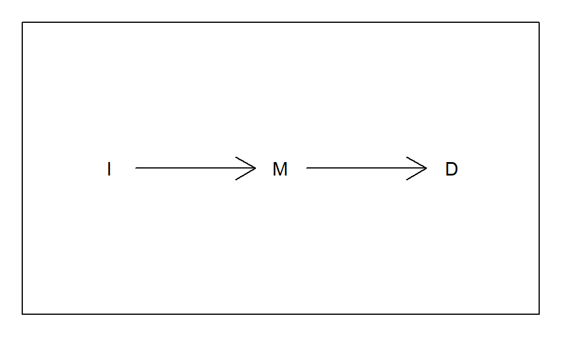

## 3.3 The nodes

The nodes are variables that can take on different values for each unit as a function of the values of other nodes that precede it in the causal ordering:

Suppose we believe that inequality ($I$) can cause democratization ($D$) through mass mobilization ($M$).

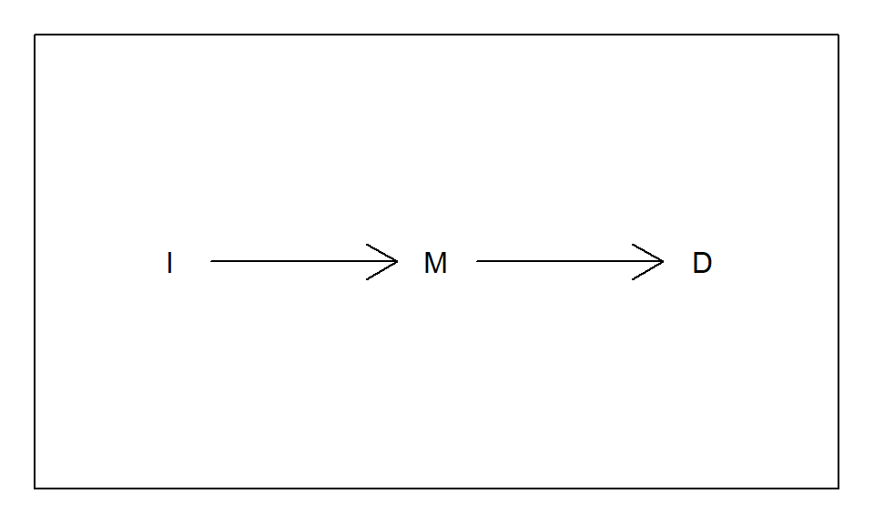

## 3.4 $\theta$ terms: random disturbances

- A $\theta$ term for each variable (Pearl uses a $U$ here)
- Represent exogenous variation affecting the system
- Think: unexplained prior conditions, features of context, random disturbances
- For us: these will capture the *way* a “child” responds to its parents

## 3.5 DAG grammar

- Node: a variable with a specified range
- Edge: an arrow connecting two nodes
  - Implies *possible* causal dependency
  - Only *direct* dependencies are connected
  - **No edge** $\Rightarrow$ **no causal dependency**

## 3.6 DAG grammar: prohibitions

- No causal cycles: “acyclic”

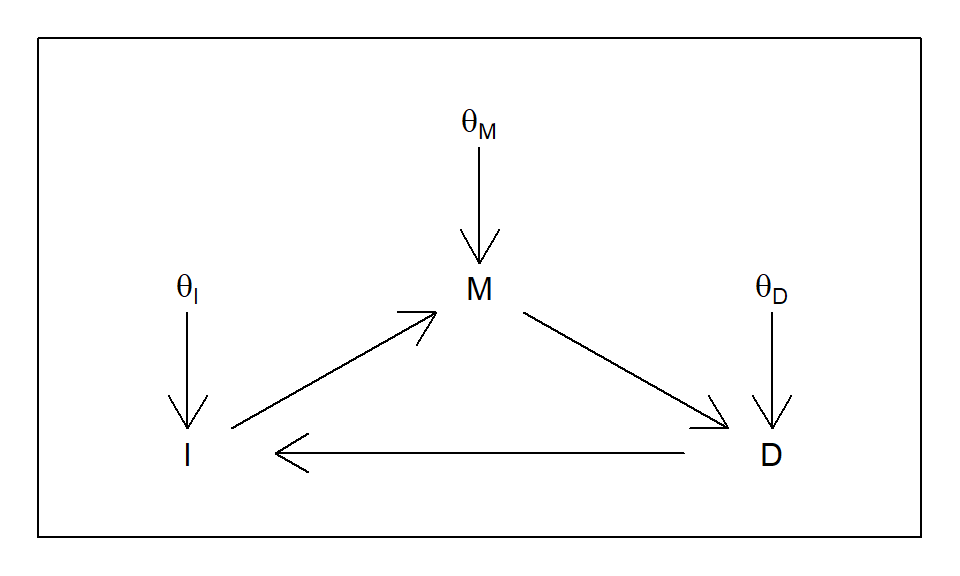

## 3.7 DAG grammar

*Not* represented on the DAG:

- Ranges of variables
- Functional relationships
  - E.g., does $I$ have a positive or negative effect on $M$?
- Beliefs about the distributions of $\theta$ terms

## 3.11 Assumptions implied by a DAG

- Similarly, implies no confounding between $I$ and $D$
- We can allow for confounding with double-headed arrows

## 3.12 Assumptions implied by a DAG

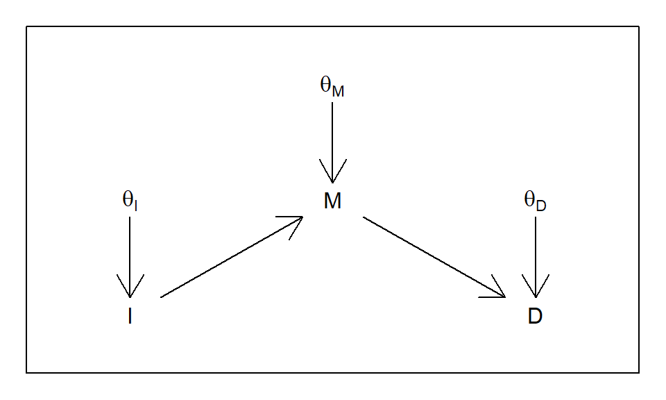

- Absent arrows mean NO direct effect
  - Here, we assume any effect of $I$ *must* run through $M$
  - A strong assumption: that we *know* the mechanism

## 3.14 DAG lingo: all in the family

We use familial language to talk about relations among nodes

## 3.15 A model is a summary of possible relations between nodes

It is not a specific “argument” for how things work

Based on our read of the inequality and democratization literature (Acemoglu/Robinson, Boix, Haggard/Kaufman, Ansell/Samuels):

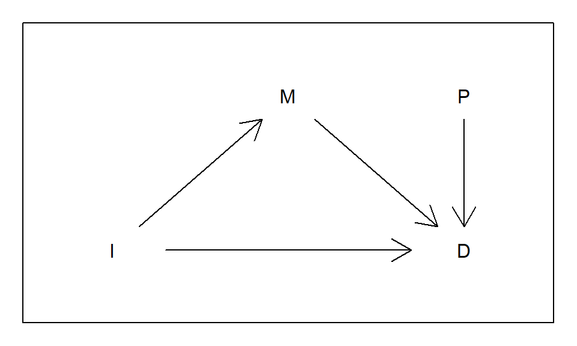

## 3.16 Example: Pierson on welfare-state cuts

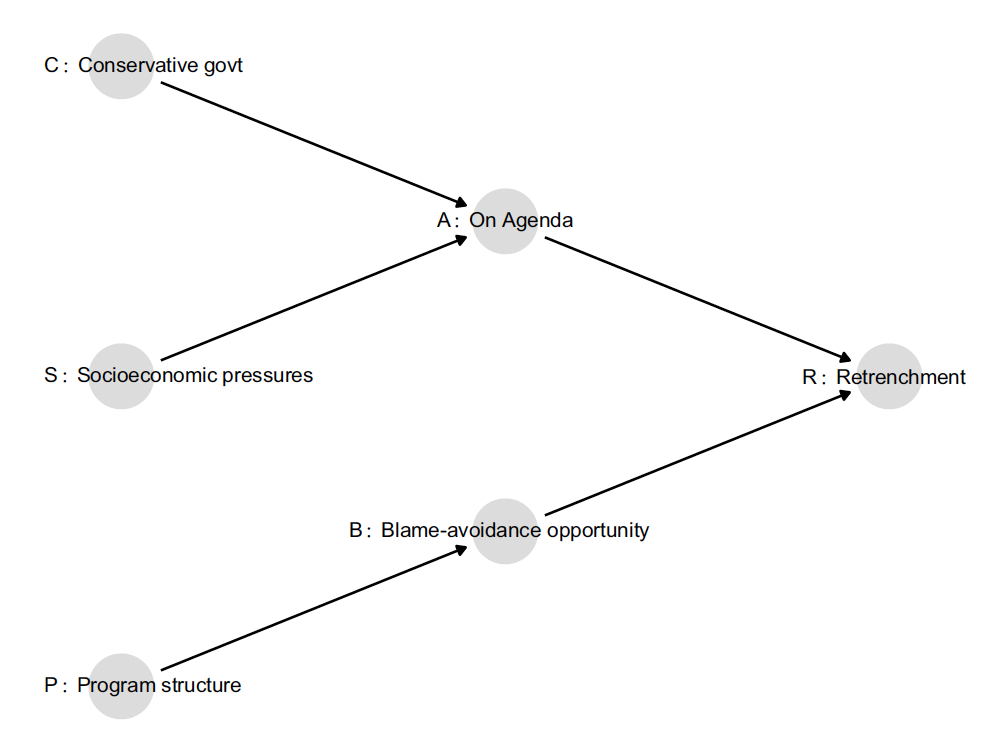

## 3.17 Causal types

A specific argument about how things work in a case might look like something like this:

- socioeconomic pressures *put* issues on the agenda; being on the agenda and having an opportunity to avoid blame were individually necessary and jointly sufficient for retrenchment
- formally this involves a specification of the $\theta$s. The $\theta$s can be used to indicate *how* a given child reacts to a parents value

## 3.18 Causal types

- For a node with no parents: $\theta$ simply indicates the nodes value. e.g. 0 or 1.
- For a node with one parent: $\theta$ indicates how the node would respond to each value of its parents. For instance:
- $Y=0$ regardless of $X$ — we will call this “$\theta^Y =$ ‘00’”
- $Y=1$ if and only if $X=1$ — we will call this “$\theta^Y =$ ‘01’”
- $Y=1$ if and only if $X=0$ — we will call this “$\theta^Y =$ ‘10’”
- $Y=1$ regardless of $X$ — we will call this “$\theta^Y =$ ‘11’”
- For a node with $k$ parents: $\theta$ can take on up to $2^{\left(2^k\right)}$ values! This grows quickly.
- You refine a model by specificying which types are possible or which types are *likely*

# 4 Making and plotting models in `CausalQueries`

## 4.1 Making models

### 4.1.1 Causal statements

The key input to model creation is the causal statement:

- “X -> Y”
- “A -> B -> C <- A <-> C”
- “A -> B; B <- C”

Note:

- Arrows can go both directions
- Double headed arrows means confounding
- Parts of a statement can be separated using `;`
- Avoid spaces and special characters in names (`.`, `-`, `_`, `|`, etc.)

### 4.1.2 Causal statements

`CausalQueries` will always translate causal statements into a simple collection of connections:

```r
make_model("A -> B -> C <- A <-> C") |>
  inspect("statement")
```

```
Causal statement:
A -> B; A -> C; A <-> C; B -> C
```

Note:

- Arrows can go both directions
- Double headed arrows means confounding
- Parts of a statement can be separated using `;`

### 4.1.3 Inspect

Once a model is made there is a default generation of causal structure, causal types, parameters, priors, and so on. All elements can be examined using `inspect`:

```r
make_model("X -> Y") |>
  inspect("parameters_df")
```

```
parameters_df
Mapping of model parameters to nodal types:

  param_names: name of parameter
  node:        name of endogeneous node associated
               with the parameter
  gen:         partial causal ordering of the
               parameter's node
  param_set:   parameter groupings forming a simplex
  given:       if model has confounding gives
               conditioning nodal type
  param_value: parameter values
  priors:      hyperparameters of the prior
               Dirichlet distribution

  param_names node gen param_set nodal_type given param_value priors
1         X.0    X   1         X          0              0.50      1
2         X.1    X   1         X          1              0.50      1
3        Y.00    Y   2         Y         00              0.25      1
4        Y.10    Y   2         Y         10              0.25      1
5        Y.01    Y   2         Y         01              0.25      1
6        Y.11    Y   2         Y         11              0.25      1
```

### 4.1.4 Interpret

All the nodal types get made but they can still be hard to interpret. You can get help using `summary` or `interpret`:

```r
make_model("A -> Y <- B") |>
  interpret_type(nodes = "Y")
```

```
$Y
  index          interpretation
1  *---  Y = * if A = 0 & B = 0
2  -*--  Y = * if A = 1 & B = 0
3  --*-  Y = * if A = 0 & B = 1
4  ---*  Y = * if A = 1 & B = 1
```

### 4.1.5 Refine

There are various ways to refine a model:

- Set restrictions: `set_restrictions` removes particular “nodal types”
- Set parameters: `set_parameters` provide particular parameter values for a model
- Set priors: `set_priors` provide priors over model parameters

There are many ways to use these so consult help. e.g. `? set_restrictions`

### 4.1.6 Example 1

Say I have a model of the form `A -> B -> C`. I want to impose monotonicity (no negative effects), but I also want to assume that the `A -> B` relation is very strong:

Using natural language statements:

```r
model <-
  make_model("A -> B-> C") |>
  set_restrictions(statement = decreasing("A", "B")) |>
  set_restrictions(statement = decreasing("B", "C")) |>
  set_parameters(statement = increasing("A", "B"), parameters = .8)

model |>  inspect("parameters_df")
```

```
parameters_df
Mapping of model parameters to nodal types:

  param_names: name of parameter
  node:        name of endogeneous node associated
               with the parameter
  gen:         partial causal ordering of the
               parameter's node
  param_set:   parameter groupings forming a simplex
  given:       if model has confounding gives
               conditioning nodal type
  param_value: parameter values
  priors:      hyperparameters of the prior
               Dirichlet distribution

   param_names node gen param_set nodal_type given param_value priors
1          A.0    A   1         A          0         0.5000000      1
2          A.1    A   1         A          1         0.5000000      1
3         B.00    B   2         B         00         0.1000000      1
5         B.01    B   2         B         01         0.8000000      1
6         B.11    B   2         B         11         0.1000000      1
7         C.00    C   3         C         00         0.3333333      1
9         C.01    C   3         C         01         0.3333333      1
10        C.11    C   3         C         11         0.3333333      1
```

### 4.1.7 Example 1

Say I have a model of the form `A -> B -> C`. I want to impose monotonicity (no negative effects), but I also want to assume that the `A -> B` relation is very strong:

Using nodal types:

```r
model <-
  make_model("A -> B-> C") |>
  set_restrictions(param_names  = 'B.10') |>
  set_restrictions(param_names  = 'C.10') |>
  set_parameters(param_names = 'B.01', parameters = .8)

model |>  inspect("parameters_df")
```

```
parameters_df
Mapping of model parameters to nodal types:

  param_names: name of parameter
  node:        name of endogeneous node associated
               with the parameter
  gen:         partial causal ordering of the
               parameter's node
  param_set:   parameter groupings forming a simplex
  given:       if model has confounding gives
               conditioning nodal type
  param_value: parameter values
  priors:      hyperparameters of the prior
               Dirichlet distribution

   param_names node gen param_set nodal_type given param_value priors
1          A.0    A   1         A          0         0.5000000      1
2          A.1    A   1         A          1         0.5000000      1
3         B.00    B   2         B         00         0.1000000      1
5         B.01    B   2         B         01         0.8000000      1
6         B.11    B   2         B         11         0.1000000      1
7         C.00    C   3         C         00         0.3333333      1
9         C.01    C   3         C         01         0.3333333      1
10        C.11    C   3         C         11         0.3333333      1
```

## 4.2 Plotting

Plotting functionality makes use of the Sugiyama layout from `igraph` which plots nodes to reflect their position in a causal ordering.

The `plot` method calls `plot_model` and passes provided arguments to it.

### 4.2.1 A basic plot:

```r
model <- make_model("X -> Y")

model |> plot_model()
```

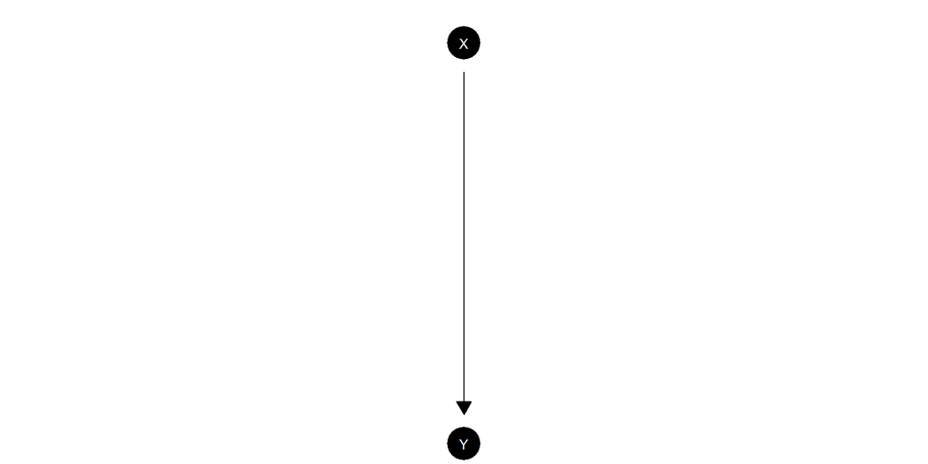

Simple model

### 4.2.2 ggplot layers

The model that is produced is a `ggplot` object and additional layers can be added in the usual way.

```r
model |>
  plot_model()  +
  annotate("text", x = c(1, -1) , y = c(1.5, 1.5), label = c("Some text", "Some more text")) +
  coord_flip()
```

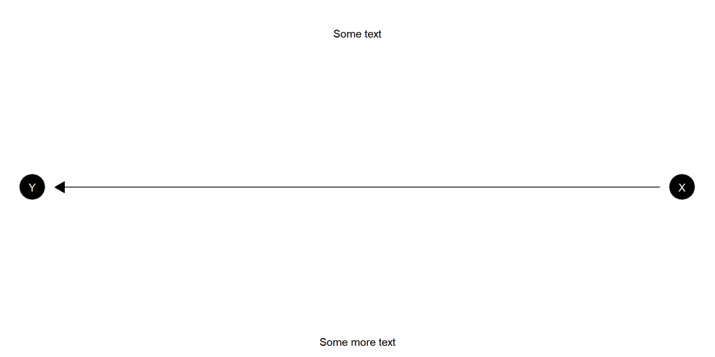

Adding additional `ggplot` layers

### 4.2.3 Adding labels

Provide labels in the same order as model nodes.

```r
model <- make_model("A -> B -> C <- A")


# Check node ordering
inspect(model, "nodes")
```

```
Nodes:
A, B, C
```

```r
# Provide labels
model |>
   plot_model(
     labels = c("This is A", "Here is B", "And C"),
     nodecol = "white", textcol = "black")
```

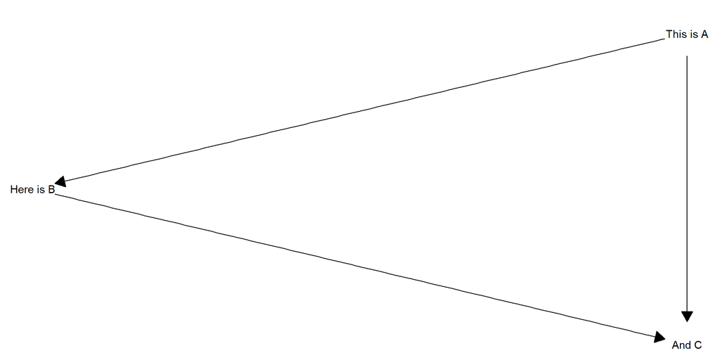

Adding labels

### 4.2.4 Controlling positions

You can manually set positions using the `x_coord` and `y_coord` arguments.

You can manually set positions using the `x_coord` and `y_coord` arguments.

```r
model |>
  plot(x_coord = 0:2,  y_coord = c(0, 2, 1))
```

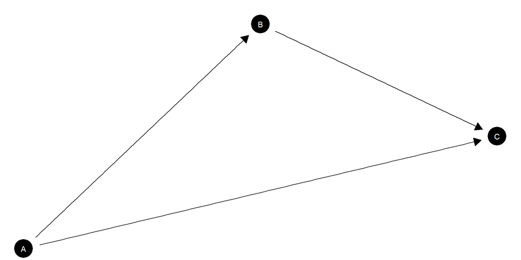

Specifying coordinates

### 4.2.5 Controlling color

You can manually control node color and text color for all nodes together or separately.

```r
model |>
  plot(x_coord = 0:2,  y_coord = c(0, 2, 1),
       nodecol = c("blue", "orange", "red"),
       textcol = c("white", "red", "blue"))
```

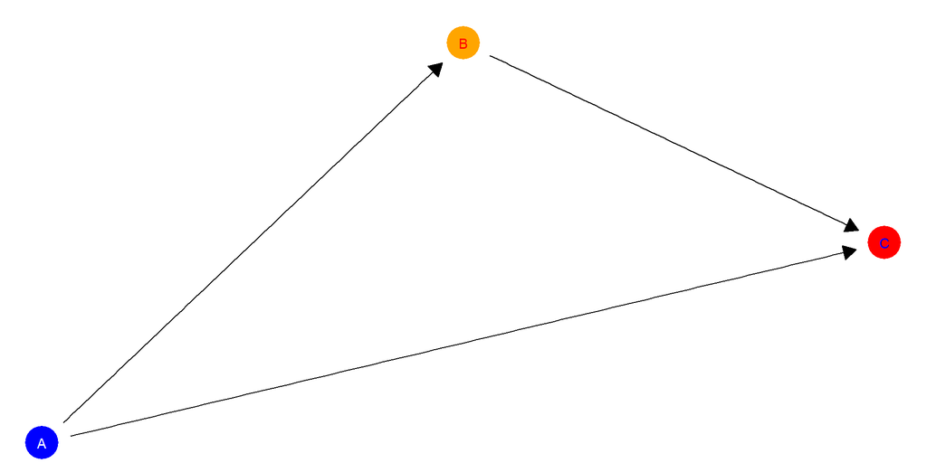

Controlling colors

### 4.2.6 Models with unobserved confounding

Unobserved confounding is represented using dashed curves.

```r
make_model('X -> K -> Y <- X; X <-> Y; K <-> Y') |>   plot()
```

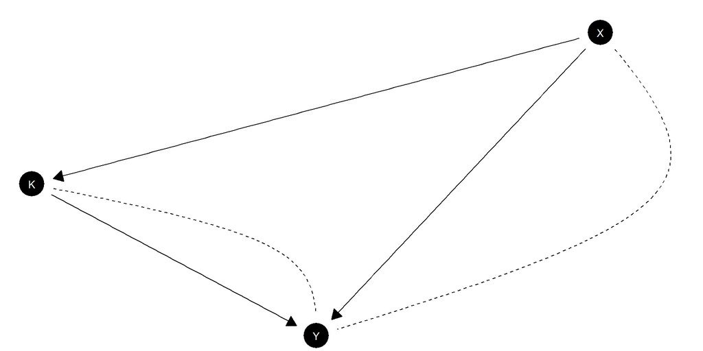

Plot showing confounding

# 5 References

### 5.0.1 References